# Geneset enrichment tests

Edoardo “Dado” Marcora

July 28, 2015

Adapted from http://pedagogix-tagc.univ-mrs.fr/courses/statistics_bioinformatics/ [http://pedagogix-tagc.univ-mrs.fr/courses/ASG1/]

# Hypergeometric test

The classical example for the hypergeometric distribution is the random selection of “k” balls in an urn containing “m” marked and “n” non-marked balls, and the observation that the selection contains “x” marked balls.

- m = number of marked balls in the urn
- N = number of balls in the urn
- n = N - m = number of non-marked balls in the urn
- k = size of the random selection
- x = number of marked balls in the random selection
- m = number of genes in geneset [e.g., number of genes annotated with EFFEROCYTOSIS, a term in GOTERM_BP_FAT]
- N = number of genes in genespace/background, e.g., number of genes in genome (or expressed genes if list of DEGs) [annotated with at least one term in GOTERM_BP_FAT]
- n = N - m
- k = number of genes in genelist [annotated with at least one term in GOTERM_BP_FAT]
- x = number of genes in overlap/intersection between genelist AND geneset [e.g., number of genes in genelist annotated with EFFEROCYTOSIS]

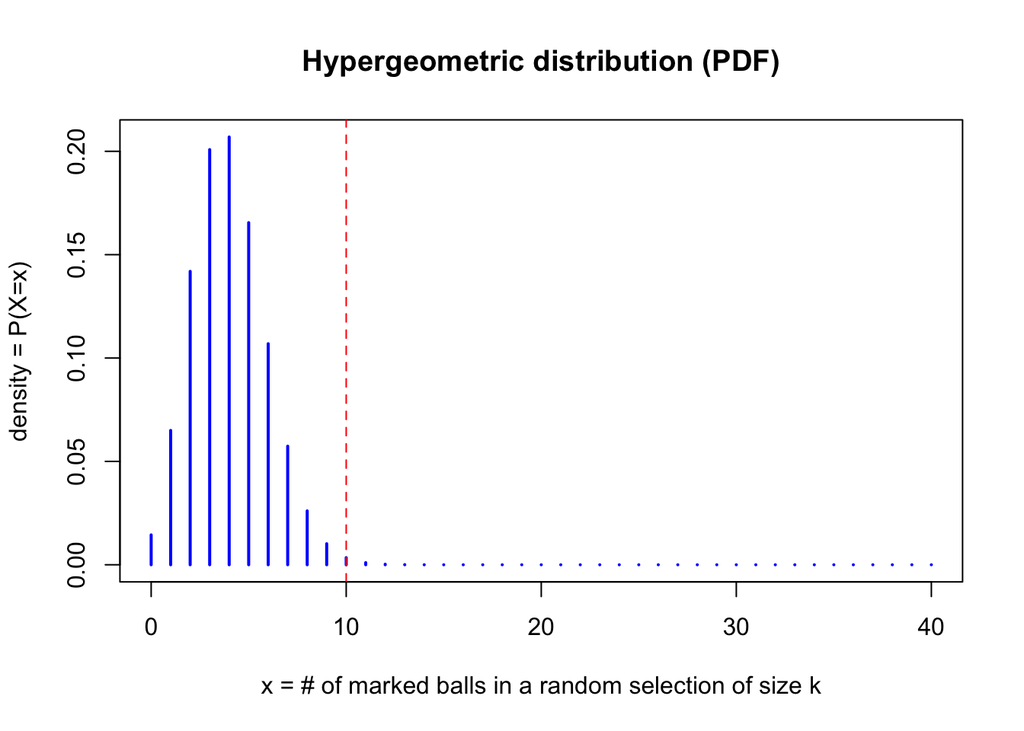

```r
k = genelist = 400
m = geneset = 40
N = genespace = 4000
n = N - m
x = 10

# x can neither be higher than k or m
x.range <- 0:min(k, m)

## probability density function (PDF) of hypergeometric distribution P(X=x)
dens = dhyper(x = x.range, m = m, n = n, k = k)

plot(x.range, dens, type = "h", lwd = 2, col = "blue", main = "Hypergeometric distribution (PDF)", xlab = "x = # of marked balls in a random selection of size k", ylab = "density = P(X=x)", ylim = c(0, max(dens)))

abline(v = x, col = "red", lty = 2)
```

The P-value is the probability of observing at least “x” marked balls in a random selection of size “k”, and it can be calculated as follows:

```r
phyper(q = x-1, m = m, n = n, k = k, lower.tail = FALSE)
```

```
## [1] 0.004836087
```

Please note that:

1. By default, the R function phyper computes the inclusive lower tail of the distribution: P(X≤x).
2. With the option “lower.tail=FALSE”, phyper() returns the exclusive upper tail P(X>x).
3. We want the inclusive upper tail: P-value = P(X≥x). For this, we can compute the exclusive upper tail of the value just below x. Indeed, since the distribution is discrete, P(X≥x) = P(X>x-1).

# Fisher’s exact test

```r
# Prepare 2x2 contingency table

contingency.table = data.frame(matrix(nrow = 2, ncol = 2))
rownames(contingency.table) = c("in.geneset", "not.in.geneset")
colnames(contingency.table) = c("in.genelist", "not.in.genelist")

contingency.table["in.geneset", "in.genelist"] = x
contingency.table["not.in.geneset", "in.genelist"] = k-x
contingency.table["in.geneset", "not.in.genelist"] = m-x
contingency.table["not.in.geneset", "not.in.genelist"] = n-(k-x)

contingency.table
```

```
##                in.genelist not.in.genelist
## in.geneset              10              30
## not.in.geneset         390            3570
```

```r
contingency.table.with.margins = cbind(contingency.table, apply(contingency.table, 1, sum))
contingency.table.with.margins = rbind(contingency.table.with.margins, apply(contingency.table.with.margins, 2, sum))

colnames(contingency.table.with.margins) = c(colnames(contingency.table), "total")
rownames(contingency.table.with.margins) = c(rownames(contingency.table), "total")

contingency.table.with.margins
```

```
##                in.genelist not.in.genelist total
## in.geneset              10              30    40
## not.in.geneset         390            3570  3960
## total                  400            3600  4000
```

```r
sum(contingency.table) # should be equal to N
```

```
## [1] 4000
```

```r
N
```

```
## [1] 4000
```

The P-value can be calculated as follows:

```r
# contingency.table = matrix(c(x, k-x, m-x, n-(k-x)), nrow = 2, ncol = 2)
ftest = fisher.test(x = contingency.table, alternative = "greater")
ftest
```

```
##
##  Fisher's Exact Test for Count Data
##
## data:  contingency.table
## p-value = 0.004836
## alternative hypothesis: true odds ratio is greater than 1
## 95 percent confidence interval:
##  1.508343      Inf
## sample estimates:
## odds ratio
##   3.049831
```

```r
ftest$p.value
```

```
## [1] 0.004836087
```